# Group Project: Analysis on Internet Usage

STA130 Fall 2018

## How to measure the internet usage of a country?

In our study, we determine the internet usage in a country by:

**Percentage of internet users in population**

```r
usage <- inner_join(internetusers, population) %>%
  mutate(Percent = usage$Users / usage$Population)
```

```r
head(usage)
```

```
## # A tibble: 6 x 4
##   Country           Users Population Percent
##   <chr>             <dbl>      <dbl>   <dbl>
## 1 China         730723960 1379302771   0.530
## 2 India         374328160 1281935911   0.292
## 3 United States 246809221  326625791   0.756
## 4 Brazil        122841218  207353391   0.592
## 5 Japan         116565962  126451398   0.922
## 6 Russia        108772470  142257519   0.765
```

## Data Source

- CIA World Fact book 2017
  - Internet Users
  - Population
  - GDP Per Capita
  - Education Expenditures
  - Life Expectancy at birth
  - Health Expenditures
- Democracy Index 2017
- Wikipedia: Regional Classifications

## Democracy on Internet Usage: Definition

**How do measure democracy?**

Here we use the data from democracy index developed by the Economist Intelligence Unit. In this study, the democracy is measured by the score in the index.

After we tidy and join the data:

```r
head(internet_demo)
```

```
## # A tibble: 6 x 6
##   Country           Users Population Percent Score Category
##   <chr>             <dbl>      <dbl>   <dbl> <dbl> <fct>
## 1 China         730723960 1379302771   0.530  3.1  Authoritarian
## 2 India         374328160 1281935911   0.292  7.23 Flawed democracy
## 3 United States 246809221  326625791   0.756  7.98 Flawed democracy
## 4 Brazil        122841218  207353391   0.592  6.86 Flawed democracy
## 5 Japan         116565962  126451398   0.922  7.88 Flawed democracy
## 6 Russia        108772470  142257519   0.765  3.17 Authoritarian
```

## Democracy on Internet Usage: Association

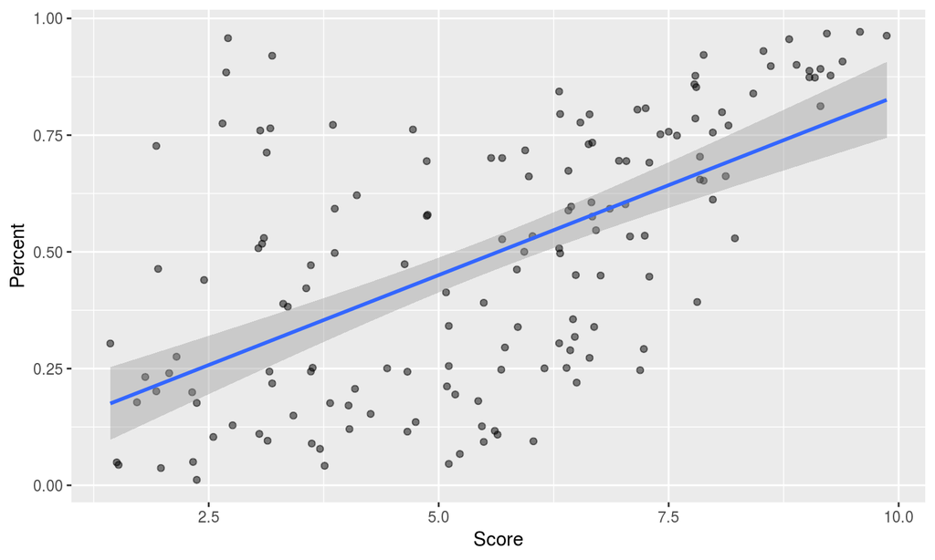

## Democracy on Internet Usage: Association

```
##
## Call:
## lm(formula = Percent ~ Score, data = internet_demo)
##
## Residuals:
##      Min       1Q   Median       3Q      Max
## -0.43530 -0.18077  0.00475  0.14439  0.68386
##
## Coefficients:
##             Estimate Std. Error t value Pr(>|t|)
## (Intercept) 0.065091   0.050490   1.289    0.199
## Score       0.077045   0.008501   9.063 5.68e-16 ***
## ---
## Signif. codes:  0 '***' 0.001 '**' 0.01 '*' 0.05 '.' 0.1 ' ' 1
##
## Residual standard error: 0.228 on 153 degrees of freedom
## Multiple R-squared:  0.3493, Adjusted R-squared:  0.3451
## F-statistic: 82.14 on 1 and 153 DF,  p-value: 5.676e-16
```

## Democracy on Internet Usage: A Closer Look

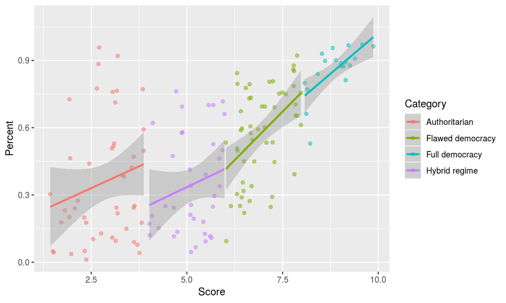

## Economy on Internet Usage: Definition

In this study we will use GDP per capita to measure the economy situation of a country.

After we tidy and join the data:

```r
head(internet_econ)
```

```
## # A tibble: 6 x 5
##   Country           Users Population Percent   GDP
##   <chr>             <dbl>      <dbl>   <dbl> <dbl>
## 1 China         730723960 1379302771   0.530 16700
## 2 India         374328160 1281935911   0.292  7200
## 3 United States 246809221  326625791   0.756 59500
## 4 Brazil        122841218  207353391   0.592 15600
## 5 Japan         116565962  126451398   0.922 42800
## 6 Russia        108772470  142257519   0.765 27800
```

## Economy on Internet Usage: Association

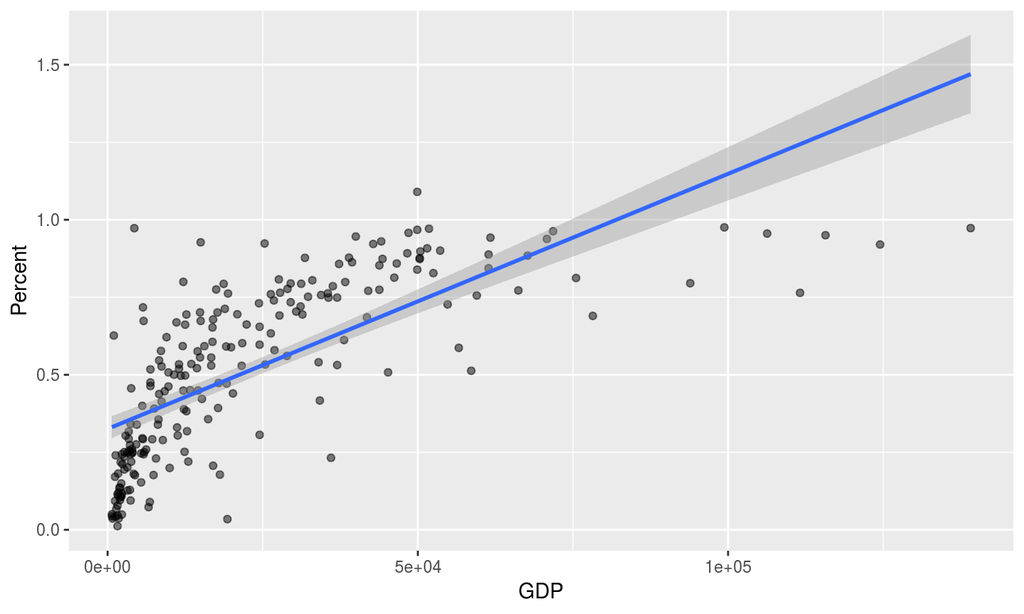

## Economy on Internet Usage: Association

```r
lm_econ <- lm(Percent ~ GDP, internet_econ)
summary(lm_econ)
```

```
##
## Call:
## lm(formula = Percent ~ GDP, data = internet_econ)
##
## Residuals:
##      Min       1Q   Median       3Q      Max
## -0.49681 -0.15099  0.01422  0.14918  0.61199
##
## Coefficients:
##              Estimate Std. Error t value Pr(>|t|)
## (Intercept) 3.254e-01  1.829e-02   17.79   <2e-16 ***
## GDP         8.228e-06  5.410e-07   15.21   <2e-16 ***
## ---
## Signif. codes:  0 '***' 0.001 '**' 0.01 '*' 0.05 '.' 0.1 ' ' 1
##
## Residual standard error: 0.1971 on 218 degrees of freedom
## Multiple R-squared:  0.5148, Adjusted R-squared:  0.5126
## F-statistic: 231.3 on 1 and 218 DF,  p-value: < 2.2e-16
```

## Education on Internet Usage: Definition

We define the education of a country by the real expenditure (Percent GDP of education * GDP per capita) on education.

We tidy and join the data, then define real expenditure.

```r
mutate(RealEdu = GDP * EduExpend * 0.01)
```

```r
head(internet_edu)
```

```
## # A tibble: 6 x 7
##   Country           Users Population Percent EduExpend   GDP RealEdu
##   <chr>             <dbl>      <dbl>   <dbl>     <dbl> <dbl>   <dbl>
## 1 India         374328160 1281935911   0.292       3.2  7200    230.
## 2 United States 246809221  326625791   0.756       5.4 59500   3213
## 3 Brazil        122841218  207353391   0.592       5.8 15600    905.
## 4 Japan         116565962  126451398   0.922       3.8 42800   1626.
## 5 Russia        108772470  142257519   0.765       4.1 27800   1140.
## 6 Mexico         73334032  124574795   0.589       5.1 19900   1015.
```

## Education on Internet Usage: Association

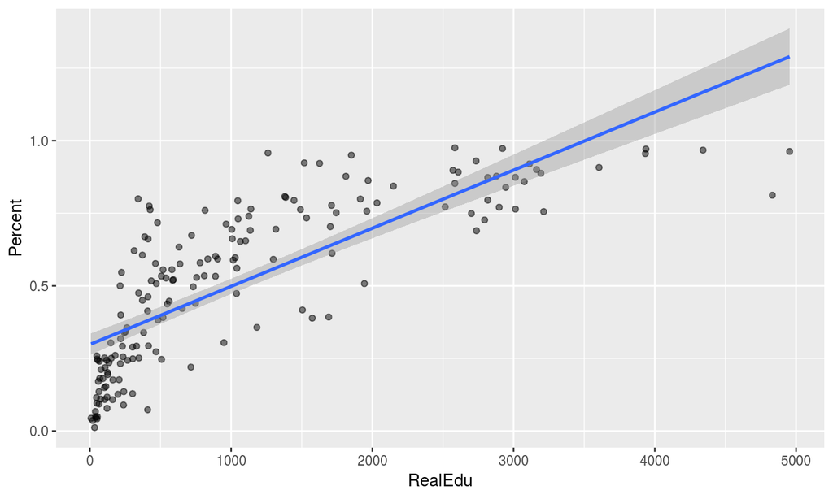

## Education on Internet Usage: Association

```
##
## Call:
## lm(formula = Percent ~ RealEdu, data = internet_edu)
##
## Residuals:
##      Min       1Q   Median       3Q      Max
## -0.45314 -0.13076 -0.01078  0.12797  0.43318
##
## Coefficients:
##              Estimate Std. Error t value Pr(>|t|)
## (Intercept) 2.982e-01  1.851e-02   16.11   <2e-16 ***
## RealEdu     2.001e-04  1.215e-05   16.47   <2e-16 ***
## ---
## Signif. codes:  0 '***' 0.001 '**' 0.01 '*' 0.05 '.' 0.1 ' ' 1
##
## Residual standard error: 0.1747 on 169 degrees of freedom
## Multiple R-squared:  0.6161, Adjusted R-squared:  0.6139
## F-statistic: 271.3 on 1 and 169 DF,  p-value: < 2.2e-16
```

## Health on Internet Usage: Definition

We will look at the real expenditure in health of the country as well as the life expectancy of its people.

We tidy and join the data, and define the real expenditure in health.

```r
mutate(RealHealth = HealthExpend * GDP * 0.01)
```

```r
head(internet_health)
```

```
## # A tibble: 6 x 5
##   Country       Percent LifeExpect AgeGroup RealHealth
##   <chr>           <dbl>      <dbl> <fct>         <dbl>
## 1 China           0.530       75.7 (70,80]        918.
## 2 India           0.292       68.8 (60,70]        338.
## 3 United States   0.756       80   (70,80]      10175.
## 4 Brazil          0.592       74   (70,80]       1295.
## 5 Japan           0.922       85.3 (80,90]       4366.
## 6 Russia          0.765       71   (70,80]       1974.
```

## Health on Internet Usage: Association

```
##
## Call:
## lm(formula = Percent ~ RealHealth + LifeExpect, data = internet_health)
##
## Residuals:
##      Min       1Q   Median       3Q      Max
## -0.44557 -0.09512 -0.00305  0.08914  0.39457
##
## Coefficients:
##               Estimate Std. Error t value Pr(>|t|)
## (Intercept) -8.956e-01  1.168e-01  -7.668 9.59e-13 ***
## RealHealth   6.582e-05  7.906e-06   8.325 1.83e-14 ***
## LifeExpect   1.784e-02  1.715e-03  10.402  < 2e-16 ***
## ---
## Signif. codes:  0 '***' 0.001 '**' 0.01 '*' 0.05 '.' 0.1 ' ' 1
##
## Residual standard error: 0.1433 on 185 degrees of freedom
## Multiple R-squared:  0.7346, Adjusted R-squared:  0.7318
## F-statistic: 256.1 on 2 and 185 DF,  p-value: < 2.2e-16
```

## Health on Internet Usage: Association

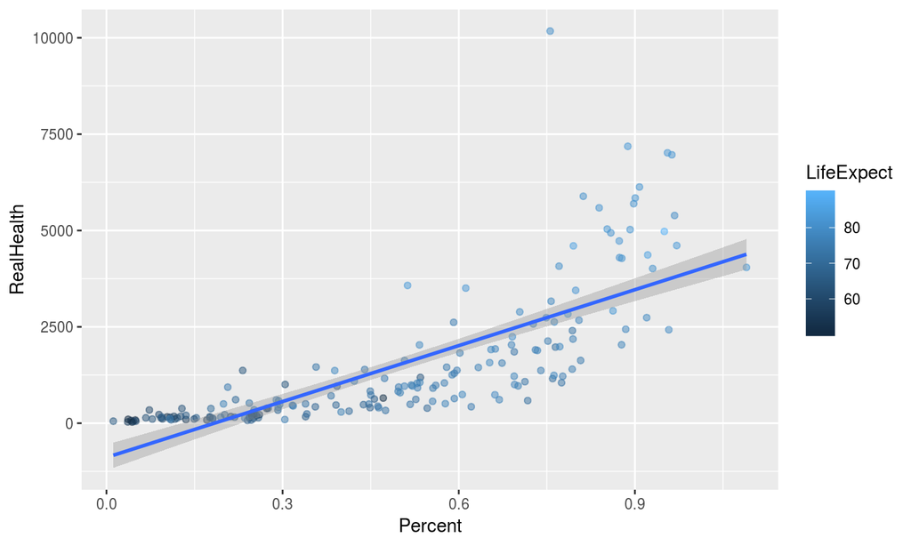

## Health on Internet Usage: A Closer look

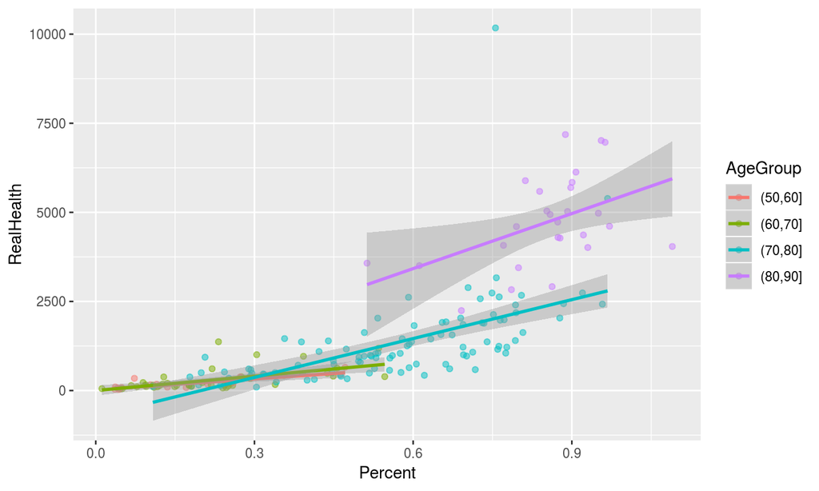

## Summary of Internet Usage in a country

### Positive association with strong evidence:

```
- Democracy
- Economy
- Health
- Education
```

### Compounding Factor: **Economy**